# M. Lautaro Hickmann

## Learning Robots Project

# Table of Contents

# Introduction

This notebook runs the OpenAi basleines (slightly modified in defaults.py in ppo2 and other small changes) implementation of the PPO algorithm (PPO2) on the MuJoCo and PyBullet implementation for 1 Million and 5 Milliossteps respectivly(using the Hyperparameters given on the PPO paper) on the Hopper experiment (Hopper-v2 and HopperBulletEnv-v0 respectively) and visualizes the results comparing them to the original paper and to the baselines given by OpenAi baselines.

## Requirements

See the README.md file for installation instructions

# Target results

## PPO-Paper

## Baseline benchmark (Orange line)

OpenAI benchmarks (http://htmlpreview.github.io/?https://github.com/openai/baselines/blob/master/benchmarks_mujoco1M.htm)

Proximal Policy Optimization Algorithms (https://arxiv.org/abs/1707.06347)

# Running the experiments

## Cleanup

### This will delete all old runs if run is set to True

## Create and run new runs

Using the hyperparameters specified in the ppo paper:

[figure not shown]

For MuJoCo training for $1.000.000$ steps and for PyBullet for $5.000.000$ steps, approximated so that enough $2048$ steps epochs can be run.

And saving $11$ videos of $1000$ steps each per run.

Note: timesteps is not exact because to be able to generate the last video one episode more is needed.

```
['OPENAI_LOG_FORMAT=csv,tensorboard OPENAI_LOGDIR="./logs/MuJoCo/MuJoCo-0"     python ./baselines/baselines/run.py --alg=ppo2 --env=Hopper-v2          --network=mlp --num_timesteps=1001472 --seed=0 --save_video_interval=100000 --save_video_length=1000',
 'OPENAI_LOG_FORMAT=csv,tensorboard OPENAI_LOGDIR="./logs/MuJoCo/MuJoCo-1"     python ./baselines/baselines/run.py --alg=ppo2 --env=Hopper-v2          --network=mlp --num_timesteps=1001472 --seed=1 --save_video_interval=100000 --save_video_length=1000',
 'OPENAI_LOG_FORMAT=csv,tensorboard OPENAI_LOGDIR="./logs/MuJoCo/MuJoCo-2"     python ./baselines/baselines/run.py --alg=ppo2 --env=Hopper-v2          --network=mlp --num_timesteps=1001472 --seed=2 --save_video_interval=100000 --save_video_length=1000',
 'OPENAI_LOG_FORMAT=csv,tensorboard OPENAI_LOGDIR="./logs/MuJoCo/MuJoCo-3"     python ./baselines/baselines/run.py --alg=ppo2 --env=Hopper-v2          --network=mlp --num_timesteps=1001472 --seed=3 --save_video_interval=100000 --save_video_length=1000',
 'OPENAI_LOG_FORMAT=csv,tensorboard OPENAI_LOGDIR="./logs/MuJoCo/MuJoCo-4"     python ./baselines/baselines/run.py --alg=ppo2 --env=Hopper-v2          --network=mlp --num_timesteps=1001472 --seed=4 --save_video_interval=100000 --save_video_length=1000',
 'OPENAI_LOG_FORMAT=csv,tensorboard OPENAI_LOGDIR="./logs/MuJoCo/MuJoCo-5"     python ./baselines/baselines/run.py --alg=ppo2 --env=Hopper-v2          --network=mlp --num_timesteps=1001472 --seed=5 --save_video_interval=100000 --save_video_length=1000',
 'OPENAI_LOG_FORMAT=csv,tensorboard OPENAI_LOGDIR="./logs/MuJoCo/MuJoCo-6"     python ./baselines/baselines/run.py --alg=ppo2 --env=Hopper-v2          --network=mlp --num_timesteps=1001472 --seed=6 --save_video_interval=100000 --save_video_length=1000',
 'OPENAI_LOG_FORMAT=csv,tensorboard OPENAI_LOGDIR="./logs/MuJoCo/MuJoCo-7"     python ./baselines/baselines/run.py --alg=ppo2 --env=Hopper-v2          --network=mlp --num_timesteps=1001472 --seed=7 --save_video_interval=100000 --save_video_length=1000',
 'OPENAI_LOG_FORMAT=csv,tensorboard OPENAI_LOGDIR="./logs/MuJoCo/MuJoCo-8"     python ./baselines/baselines/run.py --alg=ppo2 --env=Hopper-v2          --network=mlp --num_timesteps=1001472 --seed=8 --save_video_interval=100000 --save_video_length=1000',
 'OPENAI_LOG_FORMAT=csv,tensorboard OPENAI_LOGDIR="./logs/MuJoCo/MuJoCo-9"     python ./baselines/baselines/run.py --alg=ppo2 --env=Hopper-v2          --network=mlp --num_timesteps=1001472 --seed=9 --save_video_interval=100000 --save_video_length=1000',
 'OPENAI_LOG_FORMAT=csv,tensorboard OPENAI_LOGDIR="./logs/PyBullet/PyBullet-0" python ./baselines/baselines/run.py --alg=ppo2 --env=HopperBulletEnv-v0 --network=mlp --num_timesteps=5003264 --seed=0 --save_video_interval=500000 --save_video_length=1000',
 'OPENAI_LOG_FORMAT=csv,tensorboard OPENAI_LOGDIR="./logs/PyBullet/PyBullet-1" python ./baselines/baselines/run.py --alg=ppo2 --env=HopperBulletEnv-v0 --network=mlp --num_timesteps=5003264 --seed=1 --save_video_interval=500000 --save_video_length=1000',
 'OPENAI_LOG_FORMAT=csv,tensorboard OPENAI_LOGDIR="./logs/PyBullet/PyBullet-2" python ./baselines/baselines/run.py --alg=ppo2 --env=HopperBulletEnv-v0 --network=mlp --num_timesteps=5003264 --seed=2 --save_video_interval=500000 --save_video_length=1000',
 'OPENAI_LOG_FORMAT=csv,tensorboard OPENAI_LOGDIR="./logs/PyBullet/PyBullet-3" python ./baselines/baselines/run.py --alg=ppo2 --env=HopperBulletEnv-v0 --network=mlp --num_timesteps=5003264 --seed=3 --save_video_interval=500000 --save_video_length=1000',
 'OPENAI_LOG_FORMAT=csv,tensorboard OPENAI_LOGDIR="./logs/PyBullet/PyBullet-4" python ./baselines/baselines/run.py --alg=ppo2 --env=HopperBulletEnv-v0 --network=mlp --num_timesteps=5003264 --seed=4 --save_video_interval=500000 --save_video_length=1000',
 'OPENAI_LOG_FORMAT=csv,tensorboard OPENAI_LOGDIR="./logs/PyBullet/PyBullet-5" python ./baselines/baselines/run.py --alg=ppo2 --env=HopperBulletEnv-v0 --network=mlp --num_timesteps=5003264 --seed=5 --save_video_interval=500000 --save_video_length=1000',
 'OPENAI_LOG_FORMAT=csv,tensorboard OPENAI_LOGDIR="./logs/PyBullet/PyBullet-6" python ./baselines/baselines/run.py --alg=ppo2 --env=HopperBulletEnv-v0 --network=mlp --num_timesteps=5003264 --seed=6 --save_video_interval=500000 --save_video_length=1000',
 'OPENAI_LOG_FORMAT=csv,tensorboard OPENAI_LOGDIR="./logs/PyBullet/PyBullet-7" python ./baselines/baselines/run.py --alg=ppo2 --env=HopperBulletEnv-v0 --network=mlp --num_timesteps=5003264 --seed=7 --save_video_interval=500000 --save_video_length=1000',
 'OPENAI_LOG_FORMAT=csv,tensorboard OPENAI_LOGDIR="./logs/PyBullet/PyBullet-8" python ./baselines/baselines/run.py --alg=ppo2 --env=HopperBulletEnv-v0 --network=mlp --num_timesteps=5003264 --seed=8 --save_video_interval=500000 --save_video_length=1000',
 'OPENAI_LOG_FORMAT=csv,tensorboard OPENAI_LOGDIR="./logs/PyBullet/PyBullet-9" python ./baselines/baselines/run.py --alg=ppo2 --env=HopperBulletEnv-v0 --network=mlp --num_timesteps=5003264 --seed=9 --save_video_interval=500000 --save_video_length=1000']
```

# Visualize the experiments

Open TensorBoard to visualize each run.  
It takes approximately 5 min to show the first episode.  
If opening the html, an extra tensorboard instance must be started to load the logs.

```
Reusing TensorBoard on port 6006 (pid 1451), started 4:48:28 ago. (Use '!kill 1451' to kill it.)
```

[interactive chart not shown]

## Average return graphs

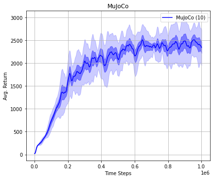

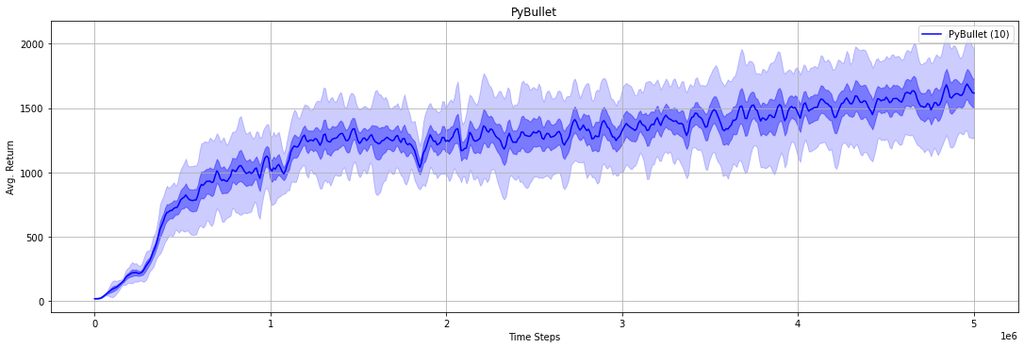

Visualization of the averages of 10 runs. Once as a small graph to better compare to the Hopper-V1 target curves, an once as a large graph to compare to the Baselines benchmarks.

The lighter shade shows the standard deviation of data, and darker shade - error in estimate of the mean (that is, standard deviation divided by square root of number of seeds). Note that averaging over seeds requires resampling to a common grid, which, in turn, requires smoothing (using language of signal processing, we need to do low-pass filtering before resampling to avoid aliasing effects).

## Gifs

```
Best run in: ./logs/MuJoCo/MuJoCo-5/videos/*.mp4
```

```
Best run in: ./logs/PyBullet/PyBullet-7/videos/*.mp4
```

```
['./logs/PyBullet/PyBullet-7/videos/vecenv.video.3527.video000000.mp4',
 './logs/PyBullet/PyBullet-7/videos/vecenv.video.3527.video500000.mp4',
 './logs/PyBullet/PyBullet-7/videos/vecenv.video.3527.video1000000.mp4',
 './logs/PyBullet/PyBullet-7/videos/vecenv.video.3527.video1500000.mp4',
 './logs/PyBullet/PyBullet-7/videos/vecenv.video.3527.video2000000.mp4',
 './logs/PyBullet/PyBullet-7/videos/vecenv.video.3527.video2500000.mp4',
 './logs/PyBullet/PyBullet-7/videos/vecenv.video.3527.video3000000.mp4',
 './logs/PyBullet/PyBullet-7/videos/vecenv.video.3527.video3500000.mp4',
 './logs/PyBullet/PyBullet-7/videos/vecenv.video.3527.video4000000.mp4',
 './logs/PyBullet/PyBullet-7/videos/vecenv.video.3527.video4500000.mp4',
 './logs/PyBullet/PyBullet-7/videos/vecenv.video.3527.video5000000.mp4']
```

### MuJoCo

```
Videos of best policiy simulated on 1000 Steps after training for:
```

| After 7e+05 steps | After 1e+06 steps | After 1e+05 steps | After 5e+05 steps | After 8e+05 steps | After 2e+05 steps |
| --- | --- | --- | --- | --- | --- |

### PyBullet

```
Videos of best policiy simulated on 1000 Steps after training for:
```

| After 0e+00 steps | After 1e+06 steps | After 2e+06 steps | After 3e+06 steps | After 4e+06 steps | After 5e+06 steps |
| --- | --- | --- | --- | --- | --- |

# Comparisson

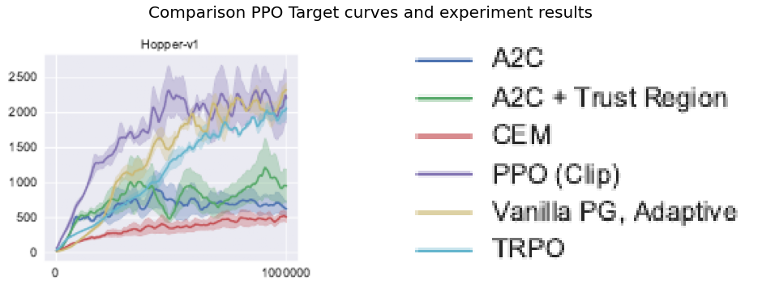

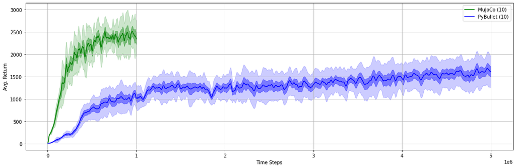

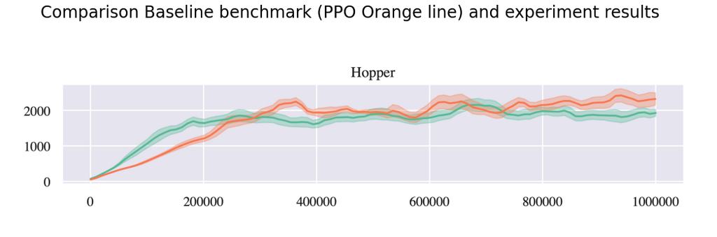

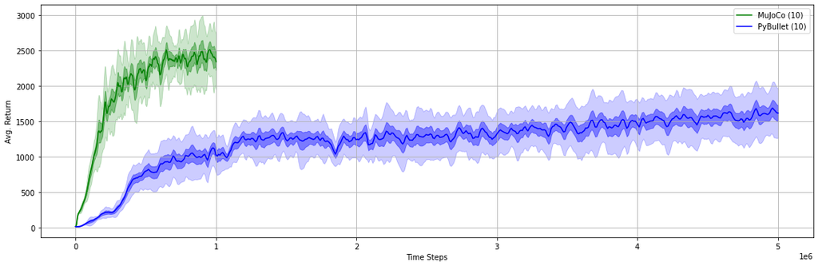

# Make html and terminate tensorboard

## This will close all running tensorboards if terminate is set to True

```
[NbConvertApp] Converting notebook visualization.ipynb to html
[NbConvertApp] Writing 1002131 bytes to visualization.html
[NbConvertApp] Converting notebook visualization.ipynb to html
[NbConvertApp] Writing 967942 bytes to no_code_visualization.html
```

[output not shown]